# Understanding Natural Language Interpretation

Semantic relationships between sentences are applied in various fields like in machine translation and sentiment analysis. As the same sentence can be said in a different way with a lot of alterations, detecting duplicate questions or finding the similarity between sentences is a difficult task. This process involves understanding the dataset, preprocessing the data and training different models to classify the pair of sentences as duplicate or not duplicate sentences[1]. Duplicate questions and duplicate responses are present in almost all the online forums. This is a problem as it stops a person from seeing the best response to the query or the comment that he/she has made[2]. Predicting whether a question is a duplicate or not can help the forums to automatically redirect the user queries to the already present query and response, and also help to prevent users from posting responses with a similar content which is already present.

Machine learning and deep learning algorithms are now widely used for NLP tasks. In this project, we analyzed different methods to extract the semantic relationship between pairs of sentences and classified them as duplicate or not duplicate. Our objective is to find the best solution that works well in classifying the duplicate sentences for any dataset that contains a pair of sentences. We explore various traditional NLP algorithms, Machine learning approaches, Deep learning methods, and Ensemble methods to identify duplicate sentences and questions. The datasets that we used for this analysis are Quora question pair data and MSR Paraphrase Corpus. Identifying whether a pair of questions are duplicate or not is treated as a binary classification problem.

[figure not shown]

Purpose of the study are:

To find the best combination of feature extraction techniques and Machine Learning algorithm to detect duplicate with high accuracy and F1 score

Finding the optimal parameters for the methods so that it can be applied to multiple data sets

Comparing the performance of the identified solution on multiple datasets and finding the best model that performs well on both the data set

# Executing all the modules

```python
# import statements
import pandas as pd
import numpy as np
from tqdm import tqdm
from keras.models import Sequential, Model
from keras.preprocessing.text import Tokenizer
from keras.preprocessing.sequence import pad_sequences
from keras.layers.core import Dense, Activation, Dropout
from keras.layers.embeddings import Embedding
from keras.layers.recurrent import LSTM, GRU
from keras.layers.normalization import BatchNormalization
from keras.utils import np_utils
from keras.layers import Input, concatenate, dot, Flatten, Reshape, Bidirectional, add
from keras.layers import TimeDistributed, Lambda
from keras.layers import Convolution1D, GlobalMaxPooling1D
from keras.regularizers import l2
from keras.layers import dot, Dot
from keras.activations import softmax
from keras.layers import Permute, subtract, multiply, GlobalAvgPool1D, GlobalMaxPool1D
from keras.callbacks import ModelCheckpoint
from keras import backend as K
from keras.layers.advanced_activations import PReLU
from keras.optimizers import Adadelta
import keras.backend as K
import tensorflow as tf
from keras.layers import Conv1D, MaxPooling1D, Embedding
from keras.preprocessing import sequence, text
from sklearn.model_selection import train_test_split
from sklearn.metrics import f1_score, recall_score, precision_score
import functions.utils as utils
from functions.utils import *
import models.deep_learning as deep_learning
from models.deep_learning import *
from functions.model_evaluation import *
import functions.model_evaluation
from sklearn.model_selection import train_test_split
import csv
```

```python
def write_csv(result, id_col, path):
    result_final = pd.DataFrame(data = list(zip(id_col, result)), columns = ['id', 'prediction'])
    result_final.to_csv(path, index = False)
```

```python
#loading the word vector
file_name = 'word_embedding/glove.6B.300d.txt'
embeddings = load_embedding(file_name)
```

## Quora Dataset: Preprocessing

```python
#Loading the data
df = pd.read_csv('Data/train.csv')
df['question1'] = df['question1'].apply(str)
df['question2'] = df['question2'].apply(str)
df.dropna(inplace = True)
df = df[:1000]

#training and testing
seed = 123
train, test = train_test_split(df)
q = list(train['question1']) + list(train['question2']) + list(test['question1']) + list(test['question2'])
#Creating the embedding matrix
NUM_WORDS = len(embeddings) #200000
tokenize = Tokenizer(num_words = NUM_WORDS)
tokenize.fit_on_texts(q)
word_index = tokenize.word_index

q1_train = tokenize.texts_to_sequences(train['question1'])
q2_train = tokenize.texts_to_sequences(train['question2'])
q1_test = tokenize.texts_to_sequences(test['question1'])
q2_test = tokenize.texts_to_sequences(test['question2'])

max_seq_length = max_seq_len(q1_train)
max_seq_length = max_seq_len(q2_train, max_seq_length)
max_seq_length = max_seq_len(q1_test, max_seq_length)
max_seq_length = max_seq_len(q2_test, max_seq_length)

q1_train_padded = pad_sequences(q1_train, max_seq_length)
q2_train_padded = pad_sequences(q2_train, max_seq_length)
q1_test_padded = pad_sequences(q1_test, max_seq_length)
q2_test_padded = pad_sequences(q2_test, max_seq_length)

#Matrix with the embedding weights
embedding_dim = 300
embedding_weights = create_embedding_weights(embeddings, embedding_dim, word_index, NUM_WORDS)

NUM_WORDS = len(embedding_weights)
print("NUM of Words:"+ str(NUM_WORDS))
```

```
NUM of Words:4004
```

## Deep Learning models

```python
dl = deep_learning.deepModels(embedding_dim = embedding_dim,
                embedding_weights = embedding_weights,
                max_seq_length = max_seq_length,
                NUM_WORDS = NUM_WORDS)
```

### Siamese LSTM

```python
# variables
batch_size=32
epochs=15
validation_split=.1
```

```
Train on 675 samples, validate on 75 samples
SIAMESE LSTM:
accuracy: 54.800000000000004
f1_socre:0.5182244379212516
recall_socre:0.548
precision_socre:0.7368722600151172
```

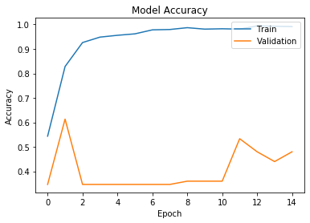

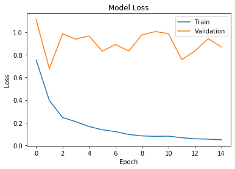

```python
lstm = dl.siamese_lstm()

hist_lstm = lstm.fit([q1_train_padded, q2_train_padded],
                     train['is_duplicate'],
                     batch_size=batch_size, epochs=epochs,
                     validation_split= validation_split)

pred_lstm = lstm.predict([q1_test_padded, q2_test_padded])

result_lstm = []
for i in pred_lstm:
    if i > .5:
        result_lstm.append(1)
    else:
        result_lstm.append(0)

count = 0
for i in range(len(result_lstm)):
    if result_lstm[i] == test['is_duplicate'].to_numpy()[i]:
        count = count +1

print("SIAMESE LSTM:")
accuracy = (count/len(result_lstm))*100
print('accuracy: ' + str(accuracy))
print('f1_socre:' + str(f1_score(test['is_duplicate'], result_lstm, average = 'weighted')))
print('recall_socre:' + str(recall_score(test['is_duplicate'], result_lstm, average = 'weighted')))
print('precision_socre:' + str(precision_score(test['is_duplicate'], result_lstm, average = 'weighted')))
plot_model_training(hist_lstm)

#write_csv(result_lstm, test['id'], 'results/deep_learning/quora/lstm.csv')
```

### Siamese GRU

```python
batch_size=100
epochs=15
validation_split=.1

gru = dl.Siamese_GRU()

hist_gru = gru.fit([q1_train_padded,
                    q2_train_padded],
                   train['is_duplicate'],
                   batch_size=batch_size,
                   epochs=epochs,
                   validation_split=validation_split)

pred_gru = gru.predict([q1_test_padded, q2_test_padded])

result_gru = []
for i in pred_gru:
    if i > .5:
        result_gru.append(1)
    else:
        result_gru.append(0)

count = 0
for i in range(len(result_gru)):
    if result_gru[i] == test['is_duplicate'].to_numpy()[i]:
        count = count +1
print("SIAMESE GRU:")
accuracy = (count/len(result_gru))*100
print("accuracy: " + str(accuracy))
print('f1_socre:' + str(f1_score(test['is_duplicate'], result_gru, average = 'weighted')))
print('recall_socre:' + str(recall_score(test['is_duplicate'], result_gru, average = 'weighted')))
print('precision_socre:' + str(precision_score(test['is_duplicate'], result_gru, average = 'weighted')))

#write_csv(result_gru, test['id'], 'results/deep_learning/quora/gru.csv')
```

```
Train on 675 samples, validate on 75 samples
SIAMESE GRU:
accuracy: 39.6
f1_socre:0.2691836464720499
recall_socre:0.396
precision_socre:0.611672268907563
```

### Siamese CNN

```
Train on 675 samples, validate on 75 samples
accuracy: 66.4
f1_socre:0.6140685483870968
recall_socre:0.664
precision_socre:0.6544425249169435
```

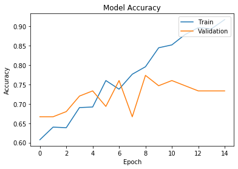

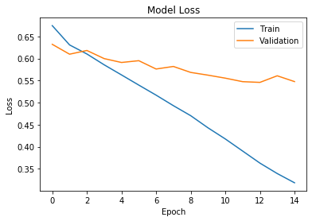

```python
batch_size = 100
epochs = 15
validation_split = 0.1

cnn = dl.siamese_cnn(filters= 16, kernel_size= 3)

hist_cnn = cnn.fit([q1_train_padded, q2_train_padded],
                   train['is_duplicate'],
                   batch_size=batch_size,
                   epochs=epochs,
                   validation_split=validation_split)

pred_cnn = cnn.predict([q1_test_padded, q2_test_padded])

result_cnn = []
for i in pred_cnn:
    if i > .5:
        result_cnn.append(1)
    else:
        result_cnn.append(0)

count = 0
for i in range(len(result_cnn)):
    if result_cnn[i] == test['is_duplicate'].to_numpy()[i]:
        count = count +1

accuracy = (count/len(result_cnn))*100
print("accuracy: " + str(accuracy))

print('f1_socre:' + str(f1_score(test['is_duplicate'], result_cnn, average = 'weighted')))
print('recall_socre:' + str(recall_score(test['is_duplicate'], result_cnn, average = 'weighted')))
print('precision_socre:' + str(precision_score(test['is_duplicate'], result_cnn, average = 'weighted')))

plot_model_training(hist_cnn)
#write_csv(result_cnn, test['id'], 'results/deep_learning/quora/cnn.csv')
```

## Deep NN

```python
batch_size = 100
epochs = 15
validation_split = 0.1

snli = dl.deep_nn()

hist_snli = snli.fit([q1_train_padded, q2_train_padded],
                   train['is_duplicate'],
                   batch_size=batch_size,
                   epochs=epochs,
                   validation_split=validation_split)

pred_snli = snli.predict([q1_test_padded, q2_test_padded])

result_snli = []
for i in pred_snli:
    if i > .5:
        result_snli.append(1)
    else:
        result_snli.append(0)

count = 0
for i in range(len(result_snli)):
    if result_snli[i] == test['is_duplicate'].to_numpy()[i]:
        count = count +1

accuracy = (count/len(result_snli))*100
print("accuracy: " + str(accuracy))

print('f1_socre:' + str(f1_score(test['is_duplicate'], result_snli, average = 'weighted')))
print('recall_socre:' + str(recall_score(test['is_duplicate'], result_snli, average = 'weighted')))
print('precision_socre:' + str(precision_score(test['is_duplicate'], result_snli, average = 'weighted')))

#write_csv(result_snli, test['id'], 'results/deep_learning/quora/deep_nn.csv')
```

```
Train on 675 samples, validate on 75 samples
accuracy: 56.39999999999999
f1_socre:0.5589895576428607
recall_socre:0.564
precision_socre:0.5553666092943201
```

### Hybrid CNN-LSTM

```
Train on 675 samples, validate on 75 samples
accuracy: 61.6
f1_socre:0.5958211091234348
recall_socre:0.616
precision_socre:0.5935706646294882
```

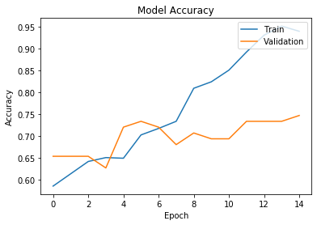

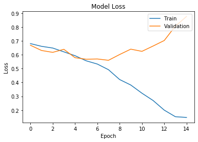

```python
batch_size = 100
epochs = 15
validation_split = 0.1

hybrid = dl.hybrid_model()

hist_hybrid = hybrid.fit([q1_train_padded, q2_train_padded],
                   train['is_duplicate'],
                   batch_size=batch_size,
                   epochs=epochs,
                   validation_split=validation_split)

pred_hybrid = hybrid.predict([q1_test_padded, q2_test_padded])

result_hybrid = []
for i in pred_hybrid:
    if i > .5:
        result_hybrid.append(1)
    else:
        result_hybrid.append(0)

count = 0
for i in range(len(result_hybrid)):
    if result_hybrid[i] == test['is_duplicate'].to_numpy()[i]:
        count = count +1

accuracy = (count/len(result_hybrid))*100
print("accuracy: " + str(accuracy))

print('f1_socre:' + str(f1_score(test['is_duplicate'], result_hybrid, average = 'weighted')))
print('recall_socre:' + str(recall_score(test['is_duplicate'], result_hybrid, average = 'weighted')))
print('precision_socre:' + str(precision_score(test['is_duplicate'], result_hybrid, average = 'weighted')))

plot_model_training(hist_hybrid)

#write_csv(result_hybrid, test['id'], 'results/deep_learning/quora/hybrid.csv')
```

### Enhanced LSTM

```
Train on 675 samples, validate on 75 samples
accuracy: 62.8
f1_socre:0.5048995692586716
recall_socre:0.628
precision_socre:0.582360655737705
```

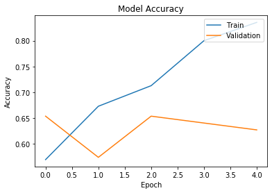

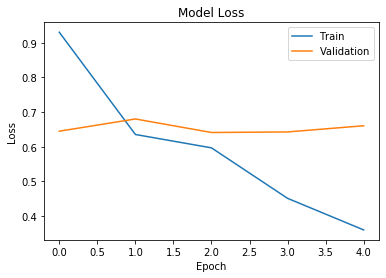

```python
batch_size = 32
epochs = 5
validation_split = .1

e_lstm = dl.enhanced_lstm()

hist_e_lstm = e_lstm.fit([q1_train_padded, q2_train_padded],
                   train['is_duplicate'],
                   batch_size=batch_size,
                   epochs=epochs,
                   validation_split=validation_split)

pred_e_lstm = e_lstm.predict([q1_test_padded, q2_test_padded])

result_elstm = []
for i in pred_e_lstm:
    if i > .5:
        result_elstm.append(1)
    else:
        result_elstm.append(0)

count = 0
for i in range(len(result_elstm)):
    if result_elstm[i] == test['is_duplicate'].to_numpy()[i]:
        count = count +1

accuracy = (count/len(result_elstm))*100
print("accuracy: "  + str(accuracy))

print('f1_socre:' + str(f1_score(test['is_duplicate'], result_elstm, average = 'weighted')))
print('recall_socre:' + str(recall_score(test['is_duplicate'], result_elstm, average = 'weighted')))
print('precision_socre:' + str(precision_score(test['is_duplicate'], result_elstm, average = 'weighted')))

plot_model_training(hist_e_lstm)

#write_csv(result_elstm, test['id'], 'results/deep_learning/quora/elstm.csv')
```

# MSR Dataset: Preprocessing

```python
# Loading the training and testing data
train = pd.read_csv(r'Data/msr_paraphrase_train.txt', sep = '\t', quoting=csv.QUOTE_NONE)
test = pd.read_csv(r'Data/msr_paraphrase_test.txt', sep = '\t', quoting=csv.QUOTE_NONE)

sent = list(train['#1 String']) + list(train['#2 String']) + list(test['#1 String']) + list(test['#2 String'])

#Creating the embedding matrix
NUM_WORDS = len(embeddings) #200000
tokenize = Tokenizer(num_words = NUM_WORDS)
tokenize.fit_on_texts(sent)
word_index = tokenize.word_index

sent1_train = tokenize.texts_to_sequences(train['#1 String'])
sent2_train = tokenize.texts_to_sequences(train['#2 String'])
sent1_test = tokenize.texts_to_sequences(test['#1 String'])
sent2_test = tokenize.texts_to_sequences(test['#2 String'])

max_seq_length = max_seq_len(sent1_train)
max_seq_length = max_seq_len(sent2_train, max_seq_length)
max_seq_length = max_seq_len(sent1_test, max_seq_length)
max_seq_length = max_seq_len(sent2_test, max_seq_length)

sent1_train_padded = pad_sequences(sent1_train, max_seq_length)
sent2_train_padded = pad_sequences(sent2_train, max_seq_length)
sent1_test_padded = pad_sequences(sent1_test, max_seq_length)
sent2_test_padded = pad_sequences(sent2_test, max_seq_length)
#Matrix with the embedding weights
embedding_dim = 300
embedding_weights = create_embedding_weights(embeddings, embedding_dim, word_index, NUM_WORDS)
NUM_WORDS = len(embedding_weights)
NUM_WORDS
```

```
16539
```

## Deep Learning Models

```python
dl = deep_learning.deepModels(embedding_dim = embedding_dim,
                embedding_weights = embedding_weights,
                max_seq_length = max_seq_length,
                NUM_WORDS = NUM_WORDS)
```

### Siamese LSTM

```
Train on 3668 samples, validate on 408 samples
accuracy:72.7536231884058
f1_socre:0.7030441542918242
recall_socre:0.7275362318840579
precision_socre:0.7163876978265604
```

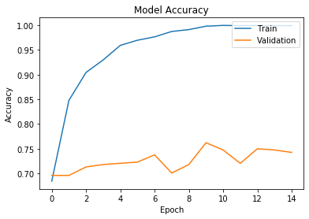

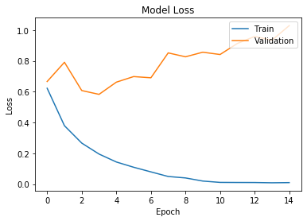

```python
batch_size=32
epochs=15
validation_split=.1

lstm = dl.siamese_lstm(dropout_lstm=None)

hist_lstm = lstm.fit([sent1_train_padded, sent2_train_padded],
                     train['Quality'],
                     batch_size=batch_size, epochs=epochs,
                     validation_split= validation_split)

pred_lstm = lstm.predict([sent1_test_padded, sent2_test_padded])

result_lstm = []
for i in pred_lstm:
    if i > .5:
        result_lstm.append(1)
    else:
        result_lstm.append(0)

count = 0
for i in range(len(result_lstm)):
    if result_lstm[i] == test['Quality'].to_numpy()[i]:
        count = count +1

accuracy = (count/len(result_lstm))*100
print('accuracy:'+ str(accuracy))

print('f1_socre:' + str(f1_score(test['Quality'], result_lstm, average = 'weighted')))
print('recall_socre:' + str(recall_score(test['Quality'], result_lstm, average = 'weighted')))
print('precision_socre:' + str(precision_score(test['Quality'], result_lstm, average = 'weighted')))

plot_model_training(hist_lstm)

#write_csv(result_lstm, test['id'], 'results/deep_learning/MSR/lstm.csv')
```

### Siamese GRU

```
Train on 3668 samples, validate on 408 samples
accuracy: 69.97101449275362
f1_socre:0.6844248987830418
recall_socre:0.6997101449275362
precision_socre:0.68354389289636
```

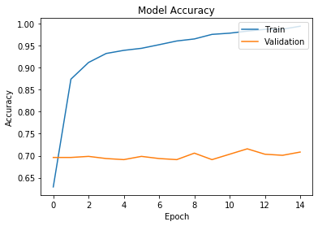

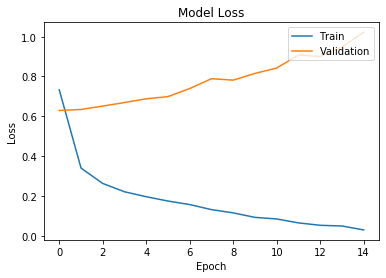

```python
batch_size=100
epochs=15
validation_split=.1

gru = dl.Siamese_GRU()

hist_gru = gru.fit([sent1_train_padded,
                    sent2_train_padded],
                   train['Quality'],
                   batch_size=batch_size,
                   epochs=epochs,
                   validation_split=validation_split)

pred_gru = gru.predict([sent1_test_padded, sent2_test_padded])

result_gru = []
for i in pred_gru:
    if i > .5:
        result_gru.append(1)
    else:
        result_gru.append(0)

count = 0
for i in range(len(result_gru)):
    if result_gru[i] == test['Quality'].to_numpy()[i]:
        count = count +1

accuracy = (count/len(result_gru))*100
print('accuracy: ' + str(accuracy))

print('f1_socre:' + str(f1_score(test['Quality'], result_gru, average = 'weighted')))
print('recall_socre:' + str(recall_score(test['Quality'], result_gru, average = 'weighted')))
print('precision_socre:' + str(precision_score(test['Quality'], result_gru, average = 'weighted')))

plot_model_training(hist_gru)

#write_csv(result_gru, test['id'], 'results/deep_learning/MSR/GRU.csv')
```

### Siamese CNN

```
Train on 3668 samples, validate on 408 samples
accuracy: 67.71014492753623
f1_socre:0.6602731288879298
recall_socre:0.6771014492753623
precision_socre:0.6574711003265467
```

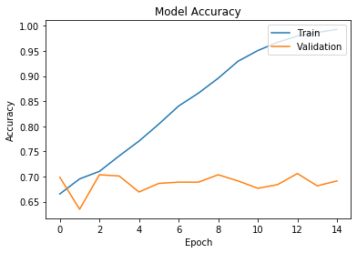

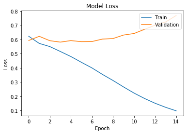

```python
batch_size = 100
epochs = 15
validation_split = 0.1


cnn = dl.siamese_cnn(filters= 16, kernel_size= 3)

hist_cnn = cnn.fit([sent1_train_padded, sent2_train_padded],
                   train['Quality'],
                   batch_size=batch_size,
                   epochs=epochs,
                   validation_split=validation_split)

pred_cnn = cnn.predict([sent1_test_padded, sent2_test_padded])

result_cnn = []
for i in pred_cnn:
    if i > .5:
        result_cnn.append(1)
    else:
        result_cnn.append(0)

count = 0
for i in range(len(result_cnn)):
    if result_cnn[i] == test['Quality'].to_numpy()[i]:
        count = count +1

accuracy = (count/len(result_cnn))*100
print("accuracy: " + str(accuracy))

print('f1_socre:' + str(f1_score(test['Quality'], result_cnn, average = 'weighted')))
print('recall_socre:' + str(recall_score(test['Quality'], result_cnn, average = 'weighted')))
print('precision_socre:' + str(precision_score(test['Quality'], result_cnn, average = 'weighted')))

plot_model_training(hist_cnn)

#write_csv(result_cnn, test['id'], 'results/deep_learning/MSR/CNN.csv')
```

### Deep NN

```
Train on 3668 samples, validate on 408 samples
accuracy: 57.507246376811594
f1_socre:0.5868401799804847
recall_socre:0.5750724637681159
precision_socre:0.621456829161177
```

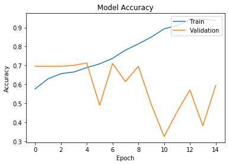

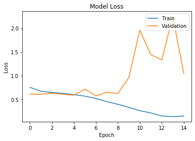

```python
batch_size = 100
epochs = 15
validation_split = 0.1

snli = dl.deep_nn()

hist_snli = snli.fit([sent1_train_padded, sent2_train_padded],
                   train['Quality'],
                   batch_size=batch_size,
                   epochs=epochs,
                   validation_split=validation_split)

pred_snli = snli.predict([sent1_test_padded, sent2_test_padded])

result_snli = []
for i in pred_snli:
    if i > .5:
        result_snli.append(1)
    else:
        result_snli.append(0)

count = 0
for i in range(len(result_snli)):
    if result_snli[i] == test['Quality'].to_numpy()[i]:
        count = count +1

accuracy = (count/len(result_snli))*100
print("accuracy: " + str(accuracy))

print('f1_socre:' + str(f1_score(test['Quality'], result_snli, average = 'weighted')))
print('recall_socre:' + str(recall_score(test['Quality'], result_snli, average = 'weighted')))
print('precision_socre:' + str(precision_score(test['Quality'], result_snli, average = 'weighted')))

plot_model_training(hist_snli)

#write_csv(result_snli, test['id'], 'results/deep_learning/MSR/Deep_NN.csv')
```

### Hybrid CNN-LSTM

```
Train on 3668 samples, validate on 408 samples
accuracy: 63.36231884057971
f1_socre:0.6134729002167567
recall_socre:0.6336231884057971
precision_socre:0.606604375170905
```

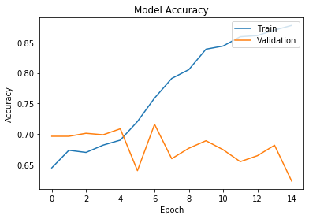

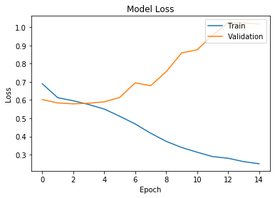

```python
batch_size = 100
epochs = 15
validation_split = 0.1

hybrid = dl.hybrid_model()

hist_hybrid = hybrid.fit([sent1_train_padded, sent2_train_padded],
                   train['Quality'],
                   batch_size=batch_size,
                   epochs=epochs,
                   validation_split=validation_split)

pred_hybrid = hybrid.predict([sent1_test_padded, sent2_test_padded])

result_hybrid = []
for i in pred_hybrid:
    if i > .5:
        result_hybrid.append(1)
    else:
        result_hybrid.append(0)

count = 0
for i in range(len(result_hybrid)):
    if result_hybrid[i] == test['Quality'].to_numpy()[i]:
        count = count +1

accuracy = (count/len(result_hybrid))*100
print('accuracy: '+ str(accuracy))


print('f1_socre:' + str(f1_score(test['Quality'], result_hybrid, average = 'weighted')))
print('recall_socre:' + str(recall_score(test['Quality'], result_hybrid, average = 'weighted')))
print('precision_socre:' + str(precision_score(test['Quality'], result_hybrid, average = 'weighted')))

plot_model_training(hist_hybrid)

#write_csv(result_hybrid, test['id'], 'results/deep_learning/MSR/hybrid.csv')
```

### Enhanced LSTM

```
Train on 3668 samples, validate on 408 samples
accuracy: 71.07246376811595
f1_socre:0.6963479358024639
recall_socre:0.7107246376811595
precision_socre:0.6962515480876463
```

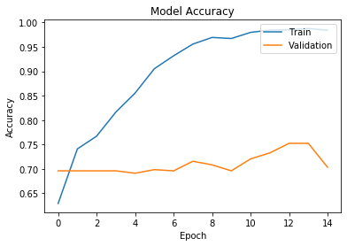

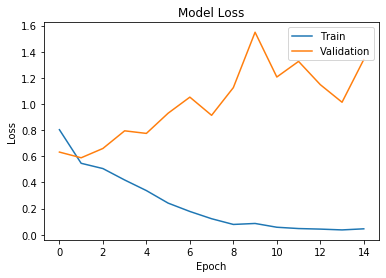

```python
batch_size = 100
epochs = 15
validation_split = 0.1

e_lstm = dl.enhanced_lstm()

hist_e_lstm = e_lstm.fit([sent1_train_padded, sent2_train_padded],
                   train['Quality'],
                   batch_size=batch_size,
                   epochs=epochs,
                   validation_split=validation_split)

pred_e_lstm = e_lstm.predict([sent1_test_padded, sent2_test_padded])

result_e_lstm = []
for i in pred_e_lstm:
    if i > .5:
        result_e_lstm.append(1)
    else:
        result_e_lstm.append(0)

count = 0
for i in range(len(result_e_lstm)):
    if result_e_lstm[i] == test['Quality'].to_numpy()[i]:
        count = count +1

accuracy = (count/len(result_e_lstm))*100
print("accuracy: " + str(accuracy))

print('f1_socre:' + str(f1_score(test['Quality'], result_e_lstm, average = 'weighted')))
print('recall_socre:' + str(recall_score(test['Quality'], result_e_lstm, average = 'weighted')))
print('precision_socre:' + str(precision_score(test['Quality'], result_e_lstm, average = 'weighted')))

plot_model_training(hist_e_lstm)

#write_csv(result_elstm, test['id'], 'results/deep_learning/MSR/elstm.csv')
```